# Chapter 4 - Workflows and Hyperparameter Tuning

Prof. Edneide Ramalho

01/08/2023

[figure not shown]

# 1 Imports

```r
library(tidyverse)
library(tidymodels)
```

# 2 Machine Learning Workflows

0. Splitting data

```r
leads_df <- readRDS("~/Documents/repos/tidymodels_in_R/datasets/leads_df.rds")

set.seed(12345)

leads_split <- initial_split(leads_df,
                             strata = purchased)

# Training data
leads_training <- leads_split %>%
  training()

# Test data
leads_test <- leads_split %>%
  testing()
```

1. **Model specification**

   ```r
   dt_model <- decision_tree() %>%
       set_engine('rpart') %>%
       set_mode('classification')
   ```

2. **Feature engineering recipe**

```r
leads_recipe <- recipe(purchased ~.,
                       data = leads_training) %>%
  step_corr(all_numeric(), threshold = 0.9) %>%
  step_normalize(all_numeric()) %>%
  step_dummy(all_nominal(), -all_outcomes())

leads_recipe
```

3. **Combining models and recipes**

```r
leads_wkfl <- workflow() %>%
  add_model(dt_model) %>%
  add_recipe(leads_recipe)

leads_wkfl
```

```
## ══ Workflow ════════════════════════════════════════════════════════════════════
## Preprocessor: Recipe
## Model: decision_tree()
##
## ── Preprocessor ────────────────────────────────────────────────────────────────
## 3 Recipe Steps
##
## • step_corr()
## • step_normalize()
## • step_dummy()
##
## ── Model ───────────────────────────────────────────────────────────────────────
## Decision Tree Model Specification (classification)
##
## Computational engine: rpart
```

4. **Model fitting with workflows**

```r
leads_wkfl_fit <- leads_wkfl %>%
  last_fit(split = leads_split)

leads_wkfl_fit %>%
  collect_metrics()
```

| .metric | .estimator | .estimate | .config |
| --- | --- | --- | --- |
| accuracy | binary | 0.8012048 | Preprocessor1_Model1 |
| roc_auc | binary | 0.8081761 | Preprocessor1_Model1 |

5. **Collecting predictions**

```r
leads_wkfl_preds <- leads_wkfl_fit %>%
  collect_predictions()

leads_wkfl_preds
```

| id | .pred_yes | .pred_no | .row | .pred_class | purchased | .config |
| --- | --- | --- | --- | --- | --- | --- |
| train/test split | 0.7382199 | 0.2617801 | 1 | yes | yes | Preprocessor1_Model1 |
| train/test split | 0.1265165 | 0.8734835 | 3 | no | no | Preprocessor1_Model1 |
| train/test split | 0.1265165 | 0.8734835 | 10 | no | no | Preprocessor1_Model1 |
| train/test split | 0.1265165 | 0.8734835 | 14 | no | no | Preprocessor1_Model1 |
| train/test split | 0.1265165 | 0.8734835 | 27 | no | no | Preprocessor1_Model1 |
| train/test split | 0.1265165 | 0.8734835 | 30 | no | no | Preprocessor1_Model1 |
| train/test split | 0.7382199 | 0.2617801 | 49 | yes | yes | Preprocessor1_Model1 |
| train/test split | 0.1265165 | 0.8734835 | 59 | no | no | Preprocessor1_Model1 |
| train/test split | 0.1265165 | 0.8734835 | 67 | no | no | Preprocessor1_Model1 |
| train/test split | 0.7382199 | 0.2617801 | 70 | yes | yes | Preprocessor1_Model1 |

[output cut: 322 more lines]

6. **Exploring custom metrics**

```r
leads_metrics <- metric_set(roc_auc, sens, spec)

leads_wkfl_preds %>%
  leads_metrics(truth = purchased,
                estimate = .pred_class,
                .pred_yes)
```

| .metric | .estimator | .estimate |
| --- | --- | --- |
| sens | binary | 0.7666667 |
| spec | binary | 0.8207547 |
| roc_auc | binary | 0.8081761 |

# 3 Loan default dataset

```r
loan_df <- readRDS("~/Documents/repos/tidymodels_in_R/datasets/loan_df.rds")
loan_df %>% glimpse()
```

```
## Rows: 872
## Columns: 8
## $ loan_default        <fct> no, yes, no, no, yes, yes, no, no, no, no, no, yes…
## $ loan_purpose        <fct> debt_consolidation, medical, small_business, small…
## $ missed_payment_2_yr <fct> no, no, no, no, yes, no, no, no, yes, no, no, no, …
## $ loan_amount         <int> 25000, 10000, 13000, 36000, 12000, 13000, 10000, 4…
## $ interest_rate       <dbl> 5.47, 10.25, 6.22, 5.97, 11.75, 13.25, 10.47, 7.97…
## $ installment         <dbl> 855.42, 363.79, 441.73, 1152.01, 307.67, 333.31, 3…
## $ annual_income       <dbl> 62823, 40000, 65000, 125000, 65000, 87000, 120000,…
## $ debt_to_income      <dbl> 39.39, 24.06, 13.96, 8.09, 20.13, 18.41, 12.79, 20…
```

# 4 Exercises - part 1

> **1. Exploring the loans dataset**

The `workflows` package provides the ability to bundle `parsnip` models and `recipe` objects into a single modeling `workflow` object. This makes managing a machine learning project much easier and removes the need to keep track of multiple modeling objects.

In this exercise, you will be working with the `loans_df` dataset, which contains financial information on consumer loans at a bank. The outcome variable in this data is `loan_default`.

You will create a **decision tree model** object and specify a feature engineering pipeline for the loan data.

- Create a data split object, `loans_split`, using the `loans_df` tibble making sure to stratify by the outcome variable.
- Create the training dataset.
- Create the test dataset.

```r
# Create data split object
loans_split <- initial_split(loan_df,
                             strata = loan_default)

# Building training data
loans_training <- loans_split %>%
  training()

# Building test data
loans_test <- loans_split %>%
  testing()
```

- Select the numeric columns from `loans_training` and create a correlation matrix.

```r
# Check for correlated predictors
loans_training %>%
  # Select numeric columns
  select_if(is.numeric) %>%
  # Calculate correlation matrix
  cor()
```

```
##                loan_amount interest_rate installment annual_income
## loan_amount     1.00000000    0.02885172  0.93538898    0.36379561
## interest_rate   0.02885172    1.00000000  0.05902337   -0.07526196
## installment     0.93538898    0.05902337  1.00000000    0.31202736
## annual_income   0.36379561   -0.07526196  0.31202736    1.00000000
## debt_to_income  0.08271718    0.16273831  0.12524882   -0.20147726
##                debt_to_income
## loan_amount        0.08271718
## interest_rate      0.16273831
## installment        0.12524882
## annual_income     -0.20147726
## debt_to_income     1.00000000
```

> **2. Specifying a model and recipe**

Now that you have created your training and test datasets, the next step is to specify your model and feature engineering pipeline. These are the two components that are needed to create a `workflow` object for the model training process.

In this exercise, you will define a decision tree model object with `decision_tree()` and a `recipe` specification with the `recipe()` function.

- Use the `decision_tree()` function to specify a decision tree classification model with the `rpart` engine.
- Create a `recipe` object with the `loans_training` data. Use all available predictor variables to predict the outcome, `loan_default`.
- Add a correlation filter to remove multicollinearity at a 0.85 threshold, normalize all numeric predictors, and create dummy variables for all nominal predictors.

```r
dt_model <- decision_tree() %>%
  # Specify the engine
  set_engine('rpart') %>%
  # Specify the mode
  set_mode('classification')

# Build feature engineering pipeline
loans_recipe <- recipe(loan_default ~.,
                        data = loans_training) %>%
  # Correlation filter
  step_corr(all_numeric(), threshold = 0.85) %>%
  # Normalize numeric predictors
  step_normalize(all_numeric()) %>%
  # Create dummy variables
  step_dummy(all_nominal(), -all_outcomes())

loans_recipe
```

> **3. Creating workflows**

`workflow` objects simplify the modeling process in `tidymodels`. With `workflows`, it’s possible to train a `parsnip` model and `recipe` object at the same time.

In this exercise, you will combine your decision tree model and feature engineering `recipe` into a single `workflow` object and perform model fitting and evaluation.

- Create a `workflow` object, `loans_dt_wkfl`, that combines your decision tree model and feature engineering `recipe`.
- Train your `workflow` with the `last_fit()` function.
- Display the performance metrics on the test dataset.

```r
# Create a workflow
loans_dt_wkfl <- workflow() %>%
  # Include the model object
  add_model(dt_model) %>%
  # Include the recipe object
  add_recipe(loans_recipe)

# View workflow specification
loans_dt_wkfl
```

```
## ══ Workflow ════════════════════════════════════════════════════════════════════
## Preprocessor: Recipe
## Model: decision_tree()
##
## ── Preprocessor ────────────────────────────────────────────────────────────────
## 3 Recipe Steps
##
## • step_corr()
## • step_normalize()
## • step_dummy()
##
## ── Model ───────────────────────────────────────────────────────────────────────
## Decision Tree Model Specification (classification)
##
## Computational engine: rpart
```

```r
# Train the workflow
loans_dt_wkfl_fit <- loans_dt_wkfl %>%
  last_fit(split = loans_split)

# Calculate performance metrics on test data
loans_dt_wkfl_fit %>%
  collect_metrics()
```

| .metric | .estimator | .estimate | .config |
| --- | --- | --- | --- |
| accuracy | binary | 0.7534247 | Preprocessor1_Model1 |
| roc_auc | binary | 0.7403863 | Preprocessor1_Model1 |

# 5 **Estimating performance with cross validation**

1. Creating cross validation folds

```r
set.seed(214)
leads_fold <- vfold_cv(leads_training,
                       v = 10,
                       strata = purchased)

leads_fold
```

| splits | id |
| --- | --- |
|  | Fold01 |
|  | Fold02 |
|  | Fold03 |
|  | Fold04 |
|  | Fold05 |
|  | Fold06 |
|  | Fold07 |
|  | Fold08 |
|  | Fold09 |
|  | Fold10 |

2. Model training with cross validation

```r
leads_rs_fit <- leads_wkfl %>%
  fit_resamples(resamples = leads_fold,
                metrics = leads_metrics)

leads_rs_fit %>%
  collect_metrics()
```

| .metric | .estimator | mean | n | std_err | .config |
| --- | --- | --- | --- | --- | --- |
| roc_auc | binary | 0.8090047 | 10 | 0.01695817 | Preprocessor1_Model1 |
| sens | binary | 0.7250000 | 10 | 0.03138602 | Preprocessor1_Model1 |
| spec | binary | 0.8584573 | 10 | 0.01286462 | Preprocessor1_Model1 |

3. DEtailed cross validation results

```r
rs_metrics <- leads_rs_fit %>%
  collect_metrics(summarize = FALSE)
rs_metrics
```

| id | .metric | .estimator | .estimate | .config |
| --- | --- | --- | --- | --- |
| Fold01 | sens | binary | 0.8611111 | Preprocessor1_Model1 |
| Fold01 | spec | binary | 0.7968750 | Preprocessor1_Model1 |
| Fold01 | roc_auc | binary | 0.8257378 | Preprocessor1_Model1 |
| Fold02 | sens | binary | 0.6666667 | Preprocessor1_Model1 |
| Fold02 | spec | binary | 0.8437500 | Preprocessor1_Model1 |
| Fold02 | roc_auc | binary | 0.7899306 | Preprocessor1_Model1 |
| Fold03 | sens | binary | 0.6111111 | Preprocessor1_Model1 |
| Fold03 | spec | binary | 0.9218750 | Preprocessor1_Model1 |
| Fold03 | roc_auc | binary | 0.7738715 | Preprocessor1_Model1 |
| Fold04 | sens | binary | 0.8333333 | Preprocessor1_Model1 |

[output cut: 20 more lines]

4. Summarizing cross validation results

```r
rs_metrics %>%
  group_by(.metric) %>%
  summarize(min = min(.estimate),
            median = median(.estimate),
            max = max(.estimate),
            mean = mean(.estimate),
            sd = sd(.estimate)
            )
```

| .metric | min | median | max | mean | sd |
| --- | --- | --- | --- | --- | --- |
| roc_auc | 0.7264109 | 0.8026896 | 0.8895503 | 0.8090047 | 0.05362646 |
| sens | 0.5833333 | 0.7222222 | 0.8611111 | 0.7250000 | 0.09925131 |
| spec | 0.7968750 | 0.8593750 | 0.9218750 | 0.8584573 | 0.04068150 |

# 6 Exercises - part 2

> 1. **Measuring performance with cross validation**

Cross validation is a method that uses training data to provide multiple estimates of model performance. When trying different model types on your data, it is important to study their performance profile to help decide which model type performs consistently well.

In this exercise, you will perform cross validation with your decision tree model `workflow` to explore its performance.

- Create a cross validation object with 5 folds using the training data, making sure to stratify by the outcome variable.

```r
# Create cross validation folds
set.seed(290)
loans_folds <- vfold_cv(loans_training, v = 5,
                   strata = loan_default)

loans_folds
```

| splits | id |
| --- | --- |
|  | Fold1 |
|  | Fold2 |
|  | Fold3 |
|  | Fold4 |
|  | Fold5 |

- Create a custom metric function that includes the area under the ROC curve (ROC AUC), sensitivity, and specificity.

```r
# Create custom metrics function
loans_metrics <- metric_set(roc_auc, sens, spec)
```

- Use your decision tree `workflow` to perform cross validation using your folds and custom metric function.

```r
# Fit resamples
loans_dt_rs <- loans_dt_wkfl %>%
  fit_resamples(resamples = loans_folds,
                metrics = loans_metrics)
```

- Explore the summarized results of your cross validation.

```r
# View performance metrics
loans_dt_rs %>%
  collect_metrics()
```

| .metric | .estimator | mean | n | std_err | .config |
| --- | --- | --- | --- | --- | --- |
| roc_auc | binary | 0.7959473 | 5 | 0.02439335 | Preprocessor1_Model1 |
| sens | binary | 0.6512157 | 5 | 0.03367840 | Preprocessor1_Model1 |
| spec | binary | 0.8927469 | 5 | 0.02457869 | Preprocessor1_Model1 |

# 7 **Cross validation with logistic regression**

Cross validation provides the ability to compare the performance profile of multiple model types. This is helpful in the early stages of modeling, when you are trying to determine which model type will perform best with your data.

In this exercise, you will perform cross validation on the `loans_training` data using logistic regression and compare the results to your decision tree model.

The `loans_folds` and `loans_metrics` objects from the previous exercise have been loaded into your session. Your feature engineering `recipe` from the previous section, `loans_recipe`, has also been loaded.

- Create a logistic regression model object with `parsnip` using the `glm` engine.
- Create a `workflow` that combines your logistic regression model and feature engineering `recipe` into one object.
- Use your logistic regression `workflow` to perform cross validation using your folds and custom metric function.
- Explore the summarized results of your cross validation.

```r
logistic_model <- logistic_reg() %>%
  # Specify the engine
  set_engine('glm') %>%
  # Specify the mode
  set_mode('classification')

# Create workflow
loans_logistic_wkfl <- workflow() %>%
  # Add model
  add_model(logistic_model) %>%
  # Add recipe
  add_recipe(loans_recipe)

# Fit resamples
loans_logistic_rs <- loans_logistic_wkfl %>%
  fit_resamples(resamples = loans_folds,
                metrics = loans_metrics)

# View performance metrics
loans_logistic_rs %>%
  collect_metrics()
```

| .metric | .estimator | mean | n | std_err | .config |
| --- | --- | --- | --- | --- | --- |
| roc_auc | binary | 0.8493525 | 5 | 0.01413902 | Preprocessor1_Model1 |
| sens | binary | 0.6589804 | 5 | 0.03067298 | Preprocessor1_Model1 |
| spec | binary | 0.8578704 | 5 | 0.01341634 | Preprocessor1_Model1 |

# 8 **Comparing model performance profiles**

The benefit of the `collect_metrics()` function is that it returns a tibble of cross validation results. This makes it easy to calculate custom summary statistics with the `dplyr` package.

In this exercise, you will use `dplyr` to explore the cross validation results of your decision tree and logistic regression models.

- - Collect the detailed cross validation results for your decision tree model.
  - Calculate the minimum, median, and maximum estimated metric values by metric type.
  - Collect the detailed cross validation results for your logistic regression model.
  - Calculate the minimum, median, and maximum estimated metric values by metric type.

```r
# Detailed cross validation results
dt_rs_results <- loans_dt_rs %>%
  collect_metrics(summarize=FALSE)

# Explore model performance for decision tree
dt_performance <- dt_rs_results %>%
  group_by(.metric) %>%
  summarize(min = min(.estimate),
            median = median(.estimate),
            max = max(.estimate))
dt_performance
```

| .metric | min | median | max |
| --- | --- | --- | --- |
| roc_auc | 0.7503676 | 0.7673687 | 0.876625 |
| sens | 0.5882353 | 0.6400000 | 0.780000 |
| spec | 0.8125000 | 0.9012346 | 0.962500 |

```r
# Detailed cross validation results
logistic_rs_results <- loans_logistic_rs %>%
  collect_metrics(summarize = FALSE)

# Explore model performance for logistic regression
logistic_performance <- logistic_rs_results %>%
  group_by(.metric) %>%
  summarize(min = min(.estimate),
            median = median(.estimate),
            max = max(.estimate))

logistic_performance
```

| .metric | min | median | max |
| --- | --- | --- | --- |
| roc_auc | 0.8110294 | 0.8554829 | 0.8885 |
| sens | 0.5490196 | 0.6800000 | 0.7200 |
| spec | 0.8250000 | 0.8518519 | 0.9000 |

```r
comparing_models <- dt_performance %>%
  bind_rows(logistic_performance) %>%
  mutate(model = c(rep('Decision Tree', 3), rep('Logistic Regression', 3)))

comparing_models
```

| .metric | min | median | max | model |
| --- | --- | --- | --- | --- |
| roc_auc | 0.7503676 | 0.7673687 | 0.876625 | Decision Tree |
| sens | 0.5882353 | 0.6400000 | 0.780000 | Decision Tree |
| spec | 0.8125000 | 0.9012346 | 0.962500 | Decision Tree |
| roc_auc | 0.8110294 | 0.8554829 | 0.888500 | Logistic Regression |
| sens | 0.5490196 | 0.6800000 | 0.720000 | Logistic Regression |
| spec | 0.8250000 | 0.8518519 | 0.900000 | Logistic Regression |

# 9 Hyperparameter tuning

## 9.1 Hyperparameters

Model parameters whose values are set prior to model training and control model complexity

`parsnip` **decision tree**

- `cost_complexity`: penalizes large number of terminal nodes
- `three_depth`: Longest path from root to terminal node
- `min_n`: Minimum data points required in a node for further splitting

Default values

- `cost_complexity`: 0.01
- `three_depth`: 30
- `min_n`: 20

## 9.2 Labeling hyperparameters for tuning

```r
dt_model <- decision_tree() %>%
  set_engine('rpart') %>%
  set_mode('classification')
```

- Use the `tune()` function from `tune` package
  - To label hyperparameters for tuning, set them equal to `tune()` in parnsnip model `specification`
  - Creates model object with tuning parameters

```r
dt_tune_model <- decision_tree(cost_complexity = tune(),
                               tree_depth = tune(),
                               min_n = tune()) %>%
  set_engine('rpart') %>%
  set_mode('classification')

  dt_tune_model
```

```
## Decision Tree Model Specification (classification)
##
## Main Arguments:
##   cost_complexity = tune()
##   tree_depth = tune()
##   min_n = tune()
##
## Computational engine: rpart
```

## 9.3 Creating a tuning workflow

`workflow` objects can be easily updated

```r
leads_tune_wkfl <- leads_wkfl %>%
  update_model(dt_tune_model)

leads_tune_wkfl
```

```
## ══ Workflow ════════════════════════════════════════════════════════════════════
## Preprocessor: Recipe
## Model: decision_tree()
##
## ── Preprocessor ────────────────────────────────────────────────────────────────
## 3 Recipe Steps
##
## • step_corr()
## • step_normalize()
## • step_dummy()
##
## ── Model ───────────────────────────────────────────────────────────────────────
## Decision Tree Model Specification (classification)
##
## Main Arguments:
##   cost_complexity = tune()
##   tree_depth = tune()
##   min_n = tune()
##
## Computational engine: rpart
```

## 9.4 Grid search

Uses a gris combination of parameters.

## 9.5 Identifying hyperparameters

```r
parameters(dt_tune_model)
```

| name | id | source | component | component_id | object |
| --- | --- | --- | --- | --- | --- |
| cost_complexity | cost_complexity | model_spec | decision_tree | main |  |
| tree_depth | tree_depth | model_spec | decision_tree | main |  |
| min_n | min_n | model_spec | decision_tree | main |  |

## 9.6 Random grid

```r
set.seed(214)

dt_grid <- grid_random(parameters(dt_tune_model),
            size = 5)
dt_grid
```

| cost_complexity | tree_depth | min_n |
| --- | --- | --- |
| 7.582908e-08 | 14 | 39 |
| 2.428094e-02 | 5 | 34 |
| 4.433492e-06 | 11 | 8 |
| 5.999125e-07 | 3 | 5 |
| 3.796558e-03 | 5 | 36 |

## 9.7 Hyperparameter tuning with cross validation

```r
dt_tunning <- leads_tune_wkfl %>%
  tune_grid(resamples = leads_fold,
            grid = dt_grid,
            metrics = leads_metrics)

dt_tunning
```

| splits | id | .metrics | .notes |
| --- | --- | --- | --- |
|  | Fold01 |  |  |
|  | Fold02 |  |  |
|  | Fold03 |  |  |
|  | Fold04 |  |  |
|  | Fold05 |  |  |
|  | Fold06 |  |  |
|  | Fold07 |  |  |
|  | Fold08 |  |  |
|  | Fold09 |  |  |
|  | Fold10 |  |  |

## 9.8 Exploring tuning results

```r
dt_tunning %>%
  collect_metrics()
```

| cost_complexity | tree_depth | min_n | .metric | .estimator | mean | n | std_err | .config |
| --- | --- | --- | --- | --- | --- | --- | --- | --- |
| 7.582908e-08 | 14 | 39 | roc_auc | binary | 0.8281839 | 10 | 0.016067433 | Preprocessor1_Model1 |
| 7.582908e-08 | 14 | 39 | sens | binary | 0.6833333 | 10 | 0.036146706 | Preprocessor1_Model1 |
| 7.582908e-08 | 14 | 39 | spec | binary | 0.8583085 | 10 | 0.018937908 | Preprocessor1_Model1 |
| 2.428094e-02 | 5 | 34 | roc_auc | binary | 0.8014102 | 10 | 0.015172271 | Preprocessor1_Model2 |
| 2.428094e-02 | 5 | 34 | sens | binary | 0.7722222 | 10 | 0.028327886 | Preprocessor1_Model2 |
| 2.428094e-02 | 5 | 34 | spec | binary | 0.8427579 | 10 | 0.011232196 | Preprocessor1_Model2 |
| 4.433492e-06 | 11 | 8 | roc_auc | binary | 0.7796193 | 10 | 0.018289863 | Preprocessor1_Model3 |
| 4.433492e-06 | 11 | 8 | sens | binary | 0.6500000 | 10 | 0.024567591 | Preprocessor1_Model3 |
| 4.433492e-06 | 11 | 8 | spec | binary | 0.8161706 | 10 | 0.009940718 | Preprocessor1_Model3 |
| 5.999125e-07 | 3 | 5 | roc_auc | binary | 0.7959894 | 10 | 0.014581385 | Preprocessor1_Model4 |

[output cut: 5 more lines]

# 10 Exercises - part 3

> 1. **Setting model hyperparameters**

Hyperparameter tuning is a method for fine-tuning the performance of your models. In most cases, the default hyperparameters values of `parsnip` model objects will not be the optimal values for maximizing model performance.

In this exercise, you will define a decision tree model with hyperparameters for tuning and create a tuning `workflow` object.

Your decision tree `workflow` object, `loans_dt_wkfl`, has been loaded into your session.

- Create a `parsnip` decision tree model and set all three of its hyperparameters for tuning.
- Use the `rpart` engine.

```r
# Set tuning hyperparameters
dt_tune_model <- decision_tree(cost_complexity = tune(),
                               tree_depth = tune(),
                               min_n = tune()) %>%
  # Specify engine
  set_engine('rpart') %>%
  # Specify mode
  set_mode('classification')

# Create a tuning workflow
loans_tune_wkfl <- loans_dt_wkfl %>%
  # Replace model
  update_model(dt_tune_model)

loans_tune_wkfl
```

```
## ══ Workflow ════════════════════════════════════════════════════════════════════
## Preprocessor: Recipe
## Model: decision_tree()
##
## ── Preprocessor ────────────────────────────────────────────────────────────────
## 3 Recipe Steps
##
## • step_corr()
## • step_normalize()
## • step_dummy()
##
## ── Model ───────────────────────────────────────────────────────────────────────
## Decision Tree Model Specification (classification)
##
## Main Arguments:
##   cost_complexity = tune()
##   tree_depth = tune()
##   min_n = tune()
##
## Computational engine: rpart
```

> 2. **Random grid search**

The most common method of hyperparameter tuning is grid search. This method creates a tuning grid with unique combinations of hyperparameter values and uses cross validation to evaluate their performance. The goal of hyperparameter tuning is to find the optimal combination of values for maximizing model performance.

In this exercise, you will create a random hyperparameter grid and tune your loans data decision tree model.

- Create a random grid of 5 hyperparameter value combinations using the hyperparameters of your `dt_tune_model` object.
- Use your `loans_tune_wkfl` object to perform hyperparameter tuning on your tuning grid with your cross validation folds and custom metrics function.
- Extract the summarized tuning results from your tuning object.

  ```r
  # Hyperparameter tuning with grid search
  set.seed(214)
  dt_grid <- grid_random(parameters(dt_tune_model),
                         size = 5)

  # Hyperparameter tuning
  dt_tuning <- loans_tune_wkfl %>%
    tune_grid(resamples = loans_folds,
              grid = dt_grid,
              metrics = loans_metrics)

  # View results
  dt_tuning %>%
    collect_metrics()
  ```

  | cost_complexity | tree_depth | min_n | .metric | .estimator | mean | n | std_err | .config |
  | --- | --- | --- | --- | --- | --- | --- | --- | --- |
  | 7.582908e-08 | 14 | 39 | roc_auc | binary | 0.8604244 | 5 | 0.010513250 | Preprocessor1_Model1 |
  | 7.582908e-08 | 14 | 39 | sens | binary | 0.6988235 | 5 | 0.026426834 | Preprocessor1_Model1 |
  | 7.582908e-08 | 14 | 39 | spec | binary | 0.8453086 | 5 | 0.023352728 | Preprocessor1_Model1 |
  | 2.428094e-02 | 5 | 34 | roc_auc | binary | 0.7827587 | 5 | 0.016253545 | Preprocessor1_Model2 |
  | 2.428094e-02 | 5 | 34 | sens | binary | 0.6470588 | 5 | 0.021071636 | Preprocessor1_Model2 |
  | 2.428094e-02 | 5 | 34 | spec | binary | 0.9078086 | 5 | 0.015951640 | Preprocessor1_Model2 |
  | 4.433492e-06 | 11 | 8 | roc_auc | binary | 0.7934638 | 5 | 0.010402972 | Preprocessor1_Model3 |
  | 4.433492e-06 | 11 | 8 | sens | binary | 0.6148235 | 5 | 0.029875404 | Preprocessor1_Model3 |
  | 4.433492e-06 | 11 | 8 | spec | binary | 0.8005556 | 5 | 0.008455128 | Preprocessor1_Model3 |
  | 5.999125e-07 | 3 | 5 | roc_auc | binary | 0.7841541 | 5 | 0.018713092 | Preprocessor1_Model4 |

  [output cut: 5 more lines]

# 11 **Exploring tuning results**

The `collect_metrics()` function is able to produce a detailed tibble of tuning results from a tuning object. Since this function returns a tibble, it works well with the `dplyr` package for further data exploration and analysis.

In this exercise, you will explore your tuning results, `dt_tuning`, to gain further insights into your hyperparameter tuning.

- Extract the detailed tuning results from your `dt_tuning` object.

  ```r
  # Collect detailed tuning results
  dt_tuning_results <- dt_tuning %>%
    collect_metrics(summarize = FALSE)

  dt_tuning_results
  ```

  | id | cost_complexity | tree_depth | min_n | .metric | .estimator | .estimate | .config |
  | --- | --- | --- | --- | --- | --- | --- | --- |
  | Fold1 | 7.582908e-08 | 14 | 39 | sens | binary | 0.6274510 | Preprocessor1_Model1 |
  | Fold1 | 7.582908e-08 | 14 | 39 | spec | binary | 0.8765432 | Preprocessor1_Model1 |
  | Fold1 | 7.582908e-08 | 14 | 39 | roc_auc | binary | 0.8402324 | Preprocessor1_Model1 |
  | Fold2 | 7.582908e-08 | 14 | 39 | sens | binary | 0.6666667 | Preprocessor1_Model1 |
  | Fold2 | 7.582908e-08 | 14 | 39 | spec | binary | 0.8000000 | Preprocessor1_Model1 |
  | Fold2 | 7.582908e-08 | 14 | 39 | roc_auc | binary | 0.8305147 | Preprocessor1_Model1 |
  | Fold3 | 7.582908e-08 | 14 | 39 | sens | binary | 0.6800000 | Preprocessor1_Model1 |
  | Fold3 | 7.582908e-08 | 14 | 39 | spec | binary | 0.8500000 | Preprocessor1_Model1 |
  | Fold3 | 7.582908e-08 | 14 | 39 | roc_auc | binary | 0.8755000 | Preprocessor1_Model1 |
  | Fold4 | 7.582908e-08 | 14 | 39 | sens | binary | 0.7600000 | Preprocessor1_Model1 |

  [output cut: 65 more lines]

- Calculate the minimum, median, and maximum area under the ROC curve for each fold in the detailed tuning results.

  ```r
  # Explore detailed ROC AUC results for each fold
  dt_tuning_results %>%
    filter(.metric == "roc_auc") %>%
    group_by(id) %>%
    summarize(min_roc_auc = min(.estimate),
              median_roc_auc = median(.estimate),
              max_roc_auc = max(.estimate))
  ```

  | id | min_roc_auc | median_roc_auc | max_roc_auc |
  | --- | --- | --- | --- |
  | Fold1 | 0.7417090 | 0.7618010 | 0.8402324 |
  | Fold2 | 0.7503676 | 0.7998775 | 0.8350490 |
  | Fold3 | 0.8087500 | 0.8296250 | 0.8905000 |
  | Fold4 | 0.8110000 | 0.8280000 | 0.8837500 |
  | Fold5 | 0.7575000 | 0.7940000 | 0.8721250 |

# 12 Selecting the best model

- The `show_best()` function displays the top `n` performing models based on average value of the `metric`.

```r
dt_tuning %>%
  show_best(metric = 'roc_auc', n = 5)
```

| cost_complexity | tree_depth | min_n | .metric | .estimator | mean | n | std_err | .config |
| --- | --- | --- | --- | --- | --- | --- | --- | --- |
| 7.582908e-08 | 14 | 39 | roc_auc | binary | 0.8604244 | 5 | 0.010513250 | Preprocessor1_Model1 |
| 3.796558e-03 | 5 | 36 | roc_auc | binary | 0.8542813 | 5 | 0.009704527 | Preprocessor1_Model5 |
| 4.433492e-06 | 11 | 8 | roc_auc | binary | 0.7934638 | 5 | 0.010402972 | Preprocessor1_Model3 |
| 5.999125e-07 | 3 | 5 | roc_auc | binary | 0.7841541 | 5 | 0.018713092 | Preprocessor1_Model4 |
| 2.428094e-02 | 5 | 34 | roc_auc | binary | 0.7827587 | 5 | 0.016253545 | Preprocessor1_Model2 |

- The `select_best()` returns a tibble with the best pdrforming model and hyperparameter values.

```r
best_dt_model <- dt_tuning %>%
  select_best(metric = 'roc_auc')

best_dt_model
```

| cost_complexity | tree_depth | min_n | .config |
| --- | --- | --- | --- |
| 7.582908e-08 | 14 | 39 | Preprocessor1_Model1 |

### 12.0.1 Finalizing the workflow

```r
final_leads_wkfl <- leads_tune_wkfl %>%
  finalize_workflow(best_dt_model)

final_leads_wkfl
```

```
## ══ Workflow ════════════════════════════════════════════════════════════════════
## Preprocessor: Recipe
## Model: decision_tree()
##
## ── Preprocessor ────────────────────────────────────────────────────────────────
## 3 Recipe Steps
##
## • step_corr()
## • step_normalize()
## • step_dummy()
##
## ── Model ───────────────────────────────────────────────────────────────────────
## Decision Tree Model Specification (classification)
##
## Main Arguments:
##   cost_complexity = 7.58290839567418e-08
##   tree_depth = 14
##   min_n = 39
##
## Computational engine: rpart
```

### 12.0.2 Model fitting

```r
leads_final_fit <- final_leads_wkfl %>%
  last_fit(split = leads_split)

leads_final_fit %>%
  collect_metrics()
```

| .metric | .estimator | .estimate | .config |
| --- | --- | --- | --- |
| accuracy | binary | 0.7710843 | Preprocessor1_Model1 |
| roc_auc | binary | 0.8248821 | Preprocessor1_Model1 |

**Behind the scenes**

- Training and test datasets created
- recipe trained and applied
- Tuned decision tree trained with entire training dataset
- Predictions and metrics on test data

# 13 Exercises - Part 4

> 1. **Finalizing a workflow**

To incorporate hyperparameter tuning into your modeling process, an optimal hyperparameter combination must be selected based on the average value of a performance metric. Then you will be able to finalize your tuning workflow and fit your final model.

In this exercise, you will explore the best performing models from your hyperparameter tuning and finalize your tuning `workflow` object.

The `dt_tuning` and `loans_tune_wkfl` objects from your previous session have been loaded into your environment.

- Display the 5 best performing hyperparameter combinations from your tuning results based on the area under the ROC curve.
- Select the best hyperparameter combination from your tuning results based on the area under the ROC curve.
- Finalize your `loans_tune_wkfl` with the best hyperparameter combination.

```r
# Display 5 best performing models
dt_tuning %>%
  show_best(metric = 'roc_auc', n = 5)
```

| cost_complexity | tree_depth | min_n | .metric | .estimator | mean | n | std_err | .config |
| --- | --- | --- | --- | --- | --- | --- | --- | --- |
| 7.582908e-08 | 14 | 39 | roc_auc | binary | 0.8604244 | 5 | 0.010513250 | Preprocessor1_Model1 |
| 3.796558e-03 | 5 | 36 | roc_auc | binary | 0.8542813 | 5 | 0.009704527 | Preprocessor1_Model5 |
| 4.433492e-06 | 11 | 8 | roc_auc | binary | 0.7934638 | 5 | 0.010402972 | Preprocessor1_Model3 |
| 5.999125e-07 | 3 | 5 | roc_auc | binary | 0.7841541 | 5 | 0.018713092 | Preprocessor1_Model4 |
| 2.428094e-02 | 5 | 34 | roc_auc | binary | 0.7827587 | 5 | 0.016253545 | Preprocessor1_Model2 |

```r
# Select based on best performance
best_dt_model <- dt_tuning %>%
  # Choose the best model based on roc_auc
  select_best(metric = 'roc_auc')

# Finalize your workflow
final_loans_wkfl <- loans_tune_wkfl %>%
  finalize_workflow(best_dt_model)

final_loans_wkfl
```

```
## ══ Workflow ════════════════════════════════════════════════════════════════════
## Preprocessor: Recipe
## Model: decision_tree()
##
## ── Preprocessor ────────────────────────────────────────────────────────────────
## 3 Recipe Steps
##
## • step_corr()
## • step_normalize()
## • step_dummy()
##
## ── Model ───────────────────────────────────────────────────────────────────────
## Decision Tree Model Specification (classification)
##
## Main Arguments:
##   cost_complexity = 7.58290839567418e-08
##   tree_depth = 14
##   min_n = 39
##
## Computational engine: rpart
```

> 2. **Training a finalized workflow**

Congratulations on successfully tuning your decision tree model and finalizing your workflow! Your `final_loans_wkfl` object can now be used for model training and prediction on new data sources.

In this last exercise, you will train your finalized `workflow` on the entire `loans_training` dataset and evaluate its performance on the `loans_test` data.

The `final_loans_wkfl` and `loans_split` objects have been loaded into your session.

- Train your finalized `workflow` with the `last_fit()` function.
- Gather the performance metrics on the test data.
- Use your trained `workflow` object to create an ROC curve.

```r
# Train finalized decision tree workflow
loans_final_fit <- final_loans_wkfl %>%
  last_fit(split = loans_split)

# View performance metrics
loans_final_fit %>%
  collect_metrics()
```

| .metric | .estimator | .estimate | .config |
| --- | --- | --- | --- |
| accuracy | binary | 0.7488584 | Preprocessor1_Model1 |
| roc_auc | binary | 0.8115891 | Preprocessor1_Model1 |

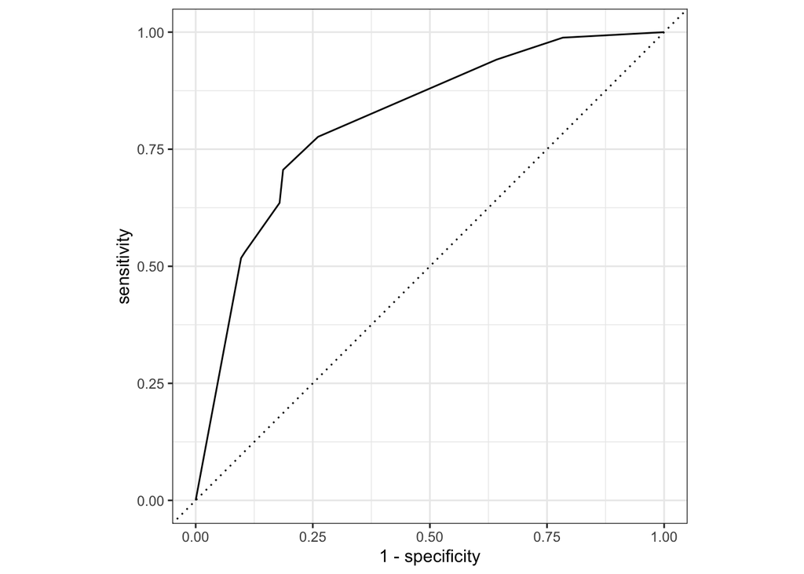

```r
# Create an ROC curve
loans_final_fit %>%
  # Collect predictions
  collect_predictions() %>%
  # Calculate ROC curve metrics
  roc_curve(truth = loan_default, .pred_yes) %>%
  # Plot the ROC curve
  autoplot()
```